# Bikeshare Project

Jason Phelps and Trevor Lebrecque

13 Nov 2020

The purpose of this analysis is to understand how weather averages for a day affect the amount of bikes that Capital Bikeshare rents out.

To Start, lets prepare the workspace:

## Preparing Workspace

To start, we loaded the packages that we may or may not use throughout the project.

```r
library(tidyverse)
library(janitor)
library(readxl)
library(skimr)
library(summarytools)
library(tidyr)
library(ggplot2)
library(lubridate)
library(sp)
```

```
Error in library(sp) : there is no package called ‘sp’
```

We had collected data from the bikeshare website as well as we found some data on the weather in DC. Each dataset shows the month of August in 2020. The weather data had the average of each metric for the day.

```r
dfa= read_excel("2020 Bikeshare.xlsx") %>% clean_names()
weather = read_excel("WeatherData.xlsx") %>% clean_names()
```

## Tidy Data

The next task is to make the data look the way we want it to for our analysis.

This first chunk gets rid of Ride_ID and then filters out the “bad” data. In the data set, we had some rides with abnormally large duration as well as negative duration. In order to prevent these datapoints from affecting our analysis, we removed them as well as ride_id, a variable we don’t need.

```r
dfb = dfa %>% select(-ride_id) %>%
  filter(duration_minutes > 0) %>% filter(duration_minutes < 1000)
```

This next chunk separates started at into day month year time. Since all data is in August of 2020, we will remove the Month and Year variables as well as all the other ones we don’t need. Puts in dfd. The last task was to take the character variable day and make it into a numeric one.

```r
dfc = dfb %>% separate(started_at, into = c("day", "time"), sep = " ") %>%
  separate(day, into = c("yearstart","monthstart","day"))
dfd <- dfc %>% select(day)
dfe = as.numeric(dfd$day)
dfd[,1] = dfe
```

For the purpose of our analysis, we need only the total number of riders for each particular day. Here we calculate that and store it in a dataframe called total_day_rider. Also make the day column into a numeric value

```r
total_day_rider = as.data.frame(table(dfd$day)) %>% rename(day = Var1, numberRiders = Freq)
dff = as.numeric(total_day_rider$day)
total_day_rider[,1] = dff
```

In the weather data, in order to allow for easy joining, we rename the variable aug to day and then join that dataframe with total_day_rider to create our overall dataset.

```r
weather = weather %>% rename(day = aug)
overall = inner_join(total_day_rider,weather,by.x = day, by.y = day)
```

## Visualizing the Data

```r
linMod <-lm(data = overall, numberRiders~pressure)
summary(linMod)
```

```
Call:
lm(formula = numberRiders ~ pressure, data = overall)

Residuals:
    Min      1Q  Median      3Q     Max
-3931.1 -1340.7   188.2  1164.3  4112.2

Coefficients:
            Estimate Std. Error t value Pr(>|t|)
(Intercept)    59367     104050   0.571    0.573
pressure       -1713       3473  -0.493    0.626

Residual standard error: 2012 on 29 degrees of freedom
Multiple R-squared:  0.008317,  Adjusted R-squared:  -0.02588
F-statistic: 0.2432 on 1 and 29 DF,  p-value: 0.6256
```

```r
linMod <-lm(data = overall, numberRiders~temp + humidity)
summary(linMod)
```

```
Call:
lm(formula = numberRiders ~ temp + humidity, data = overall)

Residuals:
    Min      1Q  Median      3Q     Max
-3247.6 -1527.8  -350.2  1187.9  4334.6

Coefficients:
            Estimate Std. Error t value Pr(>|t|)
(Intercept)  5447.26   10489.21   0.519    0.608
temp           93.72     111.86   0.838    0.409
humidity      -62.65      49.29  -1.271    0.214

Residual standard error: 1947 on 28 degrees of freedom
Multiple R-squared:  0.103, Adjusted R-squared:  0.03891
F-statistic: 1.607 on 2 and 28 DF,  p-value: 0.2184
```

```r
linMod <-lm(data = overall, numberRiders~temp + precipitation)
summary(linMod)
```

```
Call:
lm(formula = numberRiders ~ temp + precipitation, data = overall)

Residuals:
    Min      1Q  Median      3Q     Max
-3236.0 -1727.8   130.5   914.2  4244.2

Coefficients:
              Estimate Std. Error t value Pr(>|t|)
(Intercept)   -2267.57    9218.06  -0.246    0.807
temp            131.91     116.56   1.132    0.267
precipitation   -69.84     802.04  -0.087    0.931

Residual standard error: 2002 on 28 degrees of freedom
Multiple R-squared:  0.05147,   Adjusted R-squared:  -0.01628
F-statistic: 0.7598 on 2 and 28 DF,  p-value: 0.4772
```

As is made clear by each calculated p-value, there appears to be nothing statistically significant for day to day difference in the number of riders/bikeusers in the month of august. Even though is proved to be statistically insignifcant, it would appear that the two variables with the greatest impact on bike use probability day by day in the month of august is the temperature and humidity.

```r
linMod <-lm(data = overall, numberRiders~temp + precipitation + wind)
summary(linMod)
```

```
Call:
lm(formula = numberRiders ~ temp + precipitation + wind, data = overall)

Residuals:
    Min      1Q  Median      3Q     Max
-3233.0 -1698.8   164.1   885.3  4277.4

Coefficients:
              Estimate Std. Error t value Pr(>|t|)
(Intercept)   -2570.07    9455.19  -0.272    0.788
temp            140.01     122.96   1.139    0.265
precipitation    20.28     892.79   0.023    0.982
wind            -46.81     188.38  -0.248    0.806

Residual standard error: 2037 on 27 degrees of freedom
Multiple R-squared:  0.05364,   Adjusted R-squared:  -0.05151
F-statistic: 0.5101 on 3 and 27 DF,  p-value: 0.6787
```

```r
ggplot(data = overall,
       mapping = aes(x = temp,
                     y = numberRiders,
                     color = numberRiders,
                     label = line)) +
  # represent cumulative cases with lines
  geom_line(size = 0.7, alpha = 0.8) +
  # add points to line endings
  geom_point(data = overall %>% filter(temp, numberRiders)) +
  # add country labels, nudged above the lines
  geom_label_repel(nudge_y = 1, direction = "y", hjust = 1) +
  # turn off legend
  guides(color = FALSE) +
  # use pretty colors
  scale_color_viridis_d() +
  # better formatting for y-axis
  scale_y_continuous(labels = label_comma()) +
  # use minimal theme
  theme_minimal() +
  # customize labels
  labs(
    x = "temperature",
    y = "number of Riders",
    title = "Number of Riders Over Temperature Change",
    subtitle = glue("Data as of", as_of_date_formatted, .sep = " "),
    caption = ""
  )
```

```
Error: Problem with `filter()` input `..1`.
x Input `..1` must be a logical vector, not a double.
i Input `..1` is `temp`.
```

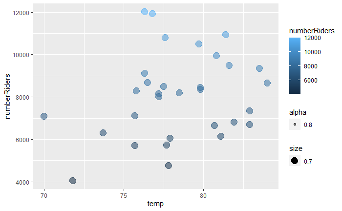

```r
#qplot(x, y, data=, color=, shape=, size=, alpha=, geom=, method=, formula=, facets=, xlim=, ylim= xlab=, ylab=, main=, sub=)
qplot(temp, numberRiders, data= overall, color=numberRiders, size=0.7, alpha=0.8)
```

```r
cor(overall$temp, overall$numberRiders)
```

```
[1] 0.2263132
```

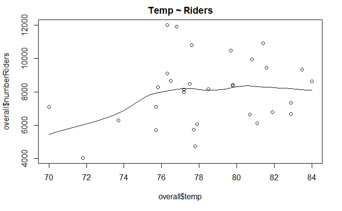

```r
scatter.smooth(x=overall$temp, y=overall$numberRiders, main="Temp ~ Riders")
```

```r
cor(overall$humidity, overall$numberRiders)
scatter.smooth(x=overall$humidity, y=overall$numberRiders, main="Humidity ~ Riders")
```

[output not shown]

```r
cor(overall$precipitation, overall$numberRiders)
scatter.smooth(x=overall$precipitation, y=overall$numberRiders, main="Precip ~ Riders")
```

[output not shown]

```r
cor(overall$wind, overall$numberRiders)
scatter.smooth(x=overall$wind, y=overall$numberRiders, main="Wind ~ Riders")
```

[output not shown]

```r
cor(overall$day, overall$numberRiders)
scatter.smooth(x=overall$day, y=overall$numberRiders, main="Day ~ Riders")
```

[output not shown]

```r
cor(overall$pressure, overall$numberRiders)
scatter.smooth(x=overall$pressure, y=overall$numberRiders, main="Humidity ~ Riders")
```

[output not shown]